# Projet Mixture model : OPTIDIGITS

#Binome: - Wacim BELAHCEL - Imad Oualid KACIMI

```r
library(R.matlab)
library(Factoshiny)
library(NbClust)
library(Rmixmod)
library(mclust)
library(clusterSim)
library(aricode)
library(h2o)
library(Rtsne)
library(tidyverse)
```

# Q1 : Introduction table de donnée

Cet ensemble de données se compose d’images vectorisées de chiffres manuscrits (0–9). Les images ont été compressées à 8x8, résultant en 64 variables

```r
Optdigits = readMat(con="C:\\Users\\GIGABYTE\\Downloads\\DATA_MATLAB - Projet-master-MLDS\\DATA_MATLAB - Projet-master-MLDS\\Optdigits.mat")
```

```r
y_data = as.data.frame(Optdigits$y)
x_data = as.data.frame(Optdigits$X)
#x_test_data = as.data.frame(mnist$testX)
#y_test_data = as.data.frame(mnist$testY)
```

```r
x_data$y<-as.factor(t(y_data))

x_data <- x_data[!duplicated(x_data[,1:64]), ]
y_data <- as.data.frame(x_data$y)
```

# Q2: ACP

Depuis le graph des individus, on remarque que les classes sont trés mélangé et qu’il est difficile de les séparé, mis à part pour la classe y_4 qui semble se démarquer legerement.

Lorsque l’on représente uniquement les modalité de la variable cible y, on peut voir que les individu des classes y_4 et y_2 contribuent fortement à la creation de l’axe 1 alors que les individidus de la classes y_7 et y_6 contribuent à la creation de l’axe 2.

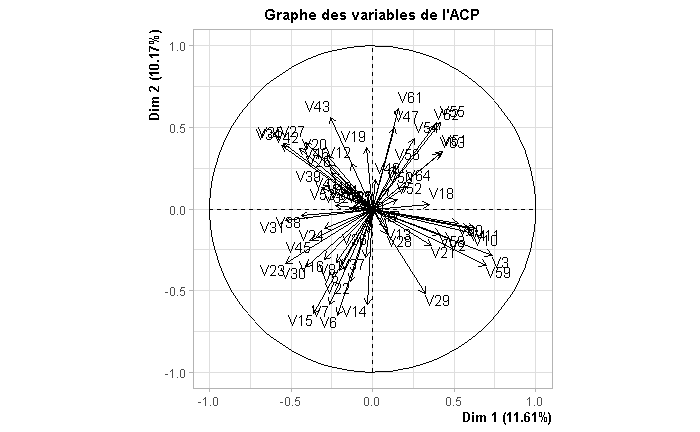

```r
res.PCA<-PCA(x_data,quali.sup=c(65),graph=FALSE)
plot.PCA(res.PCA,choix='var',title="Graphe des variables de l'ACP")
```

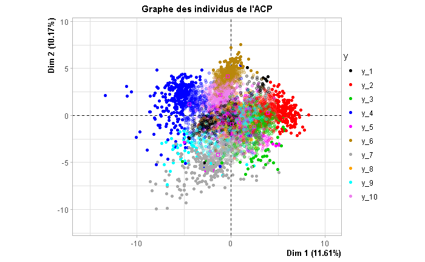

```r
plot.PCA(res.PCA,invisible=c('ind.sup'),select='contrib  794',habillage=65,title="Graphe des individus de l'ACP",label ='none')
```

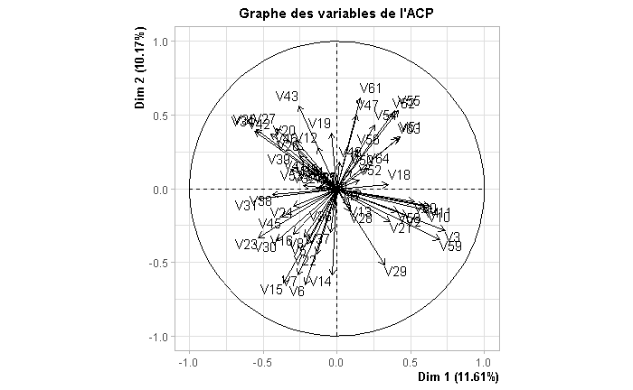

```r
res.PCA<-PCA(x_data,quali.sup=c(65),graph=FALSE)
plot.PCA(res.PCA,choix='var',title="Graphe des variables de l'ACP")
```

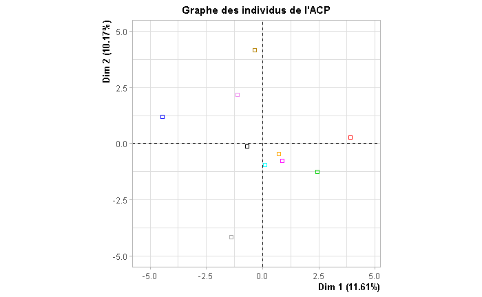

```r
plot.PCA(res.PCA,invisible=c('ind','ind.sup'),select='contrib  794',habillage=65,title="Graphe des individus de l'ACP",label =c('quali'))
```

# Q4: Clustering Kmean / CAH

La plus part des algorithme ne trouvent que 3 classes en tant que nombre optimal lorsque nous appliquons un clustering, nous pouvons donc proposer 3 classes dans ce cas la, ce qui est tres loin du nombre de classe original, la methode cah average semble cependant se rapprocher un peu plus et détecter plus de classes (7).

```r
res_cah_ward <-NbClust(x_data[,1:64], distance = "euclidean", min.nc=2, max.nc=10, method = "ward.D2",
index = "ch")
res_cah_average<-NbClust(x_data[,1:64], distance = "euclidean", min.nc=2, max.nc=10, method = "average",
index = "ch")
res_cah_complete <-NbClust(x_data[,1:64], distance = "euclidean", min.nc=2, max.nc=10, method = "complete",
index = "ch")
res_cah_single <-NbClust(x_data[,1:64], distance = "euclidean", min.nc=2, max.nc=10, method = "single",
index = "ch")
res_cah_kmeans <-NbClust(x_data[,1:64], distance = "euclidean", min.nc=2, max.nc=10, method = "kmeans",
index = "ch")
```

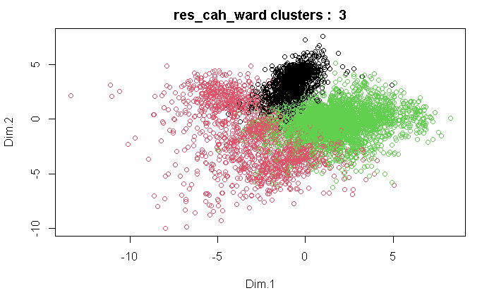

```r
plot(res.PCA$ind$coord,col=res_cah_ward$Best.partition, main = paste("res_cah_ward clusters : ",length(unique(res_cah_ward$Best.partition))))
```

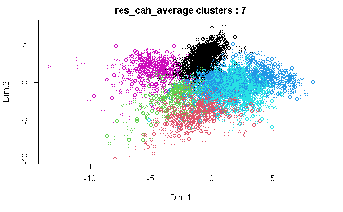

```r
plot(res.PCA$ind$coord,col=res_cah_average$Best.partition, main = paste("res_cah_average clusters :",length(unique(res_cah_average$Best.partition))))
```

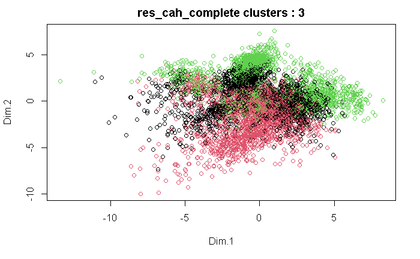

```r
plot(res.PCA$ind$coord,col=res_cah_complete$Best.partition,  main = paste("res_cah_complete clusters :",length(unique(res_cah_complete$Best.partition))))
```

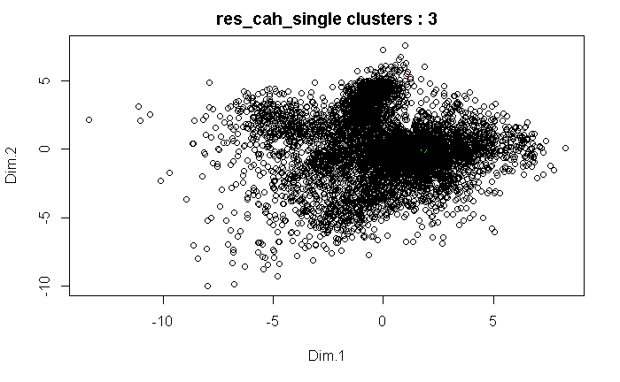

```r
plot(res.PCA$ind$coord,col=res_cah_single$Best.partition, main = paste("res_cah_single clusters :",length(unique(res_cah_single$Best.partition))))
```

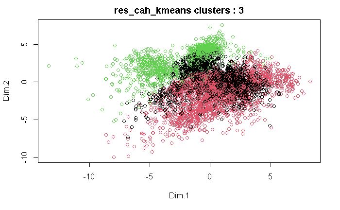

```r
plot(res.PCA$ind$coord,col=res_cah_kmeans$Best.partition, main = paste("res_cah_kmeans clusters :",length(unique(res_cah_kmeans$Best.partition))))
```

# Q5 : HCPC

En observant aussi le graph de l’inertie, on peut confirmer que nous avons un coude au niveau de la 3 éme barre. on peut donc proposer 3 classes.

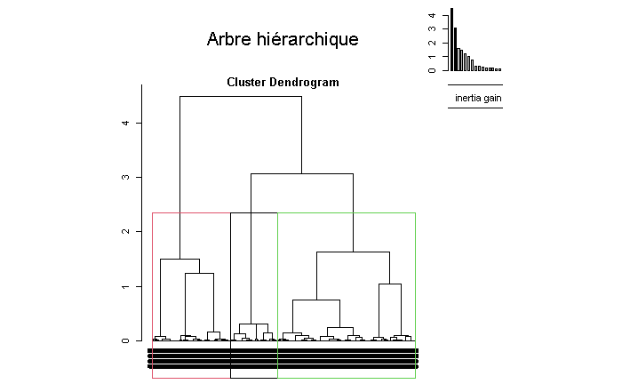

```r
res.PCA<-PCA(x_data,ncp=3,quali.sup=c(65),graph=FALSE)
res.HCPC<-HCPC(res.PCA,nb.clust=3,consol=FALSE,graph=FALSE)
plot.HCPC(res.HCPC,choice='tree',title='Arbre hiérarchique')
```

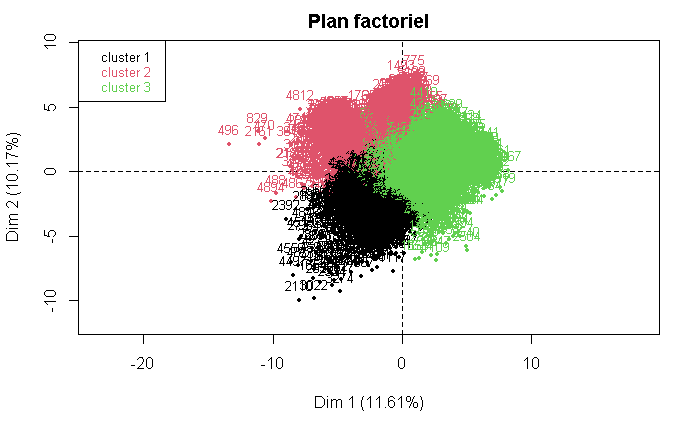

```r
plot.HCPC(res.HCPC,choice='map',draw.tree=FALSE,title='Plan factoriel')
```

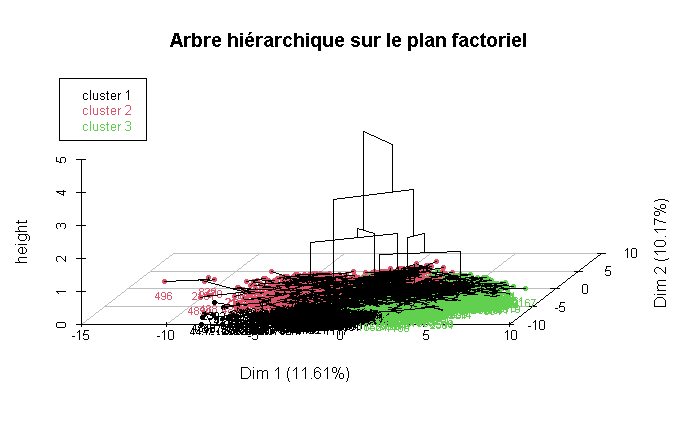

```r
plot.HCPC(res.HCPC,choice='3D.map',ind.names=TRUE,centers.plot=FALSE,angle=60,title='Arbre hiérarchique sur le plan factoriel')
```

# Q6 : comparaison avec HCPC

```r
table(as.vector(res.HCPC$data.clust[,"clust"]),as.vector(res_cah_ward$Best.partition))
```

```
       1    2    3
  1    0  824  178
  2 1073  497  105
  3   40  149 2754
```

```r
table(as.vector(res.HCPC$data.clust[,"clust"]),as.vector(res_cah_kmeans$Best.partition))
```

```
       1    2    3
  1  201  770   31
  2  619    6 1050
  3 1314 1563   66
```

```r
table(as.vector(res.HCPC$data.clust[,"clust"]),as.vector(res_cah_complete$Best.partition))
```

```
       1    2    3
  1  243  718   41
  2  735  164  776
  3  951 1132  860
```

```r
table(as.vector(res.HCPC$data.clust[,"clust"]),as.vector(res_cah_single$Best.partition))
```

```
       1    2    3
  1 1002    0    0
  2 1673    2    0
  3 2942    0    1
```

```r
table(as.vector(res.HCPC$data.clust[,"clust"]),as.vector(res_cah_average$Best.partition))
```

```
       1    2    3    4    5    6    7
  1    0  481  318   74   86   42    1
  2 1073    0   43   18   85  456    0
  3   38   91   63 1364 1378    9    0
```

# Q7 : MCLUST et RMIXMOD

```r
set.seed(1)
res.PCA<-PCA(x_data,ncp=20,quali.sup=c(65),graph=FALSE)

res.mclust=Mclust(res.PCA$ind$coord,G = 1:10)
```

```
fitting ...
```

```r
summary(res.mclust$BIC)
```

```
Best BIC values:
            VVV,10      VEV,10       VVV,9
BIC      -199979.5 -204548.742 -205919.354
BIC diff       0.0   -4569.234   -5939.847
```

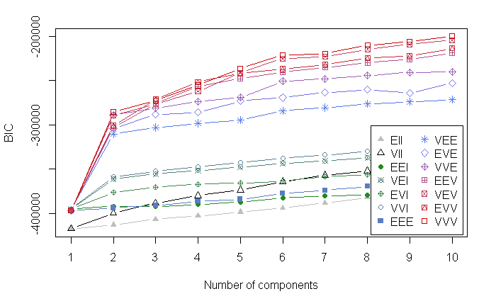

```r
plot(res.mclust,what="BIC")
```

```r
names(res.mclust)
```

```
 [1] "call"           "data"           "modelName"      "n"              "d"              "G"
 [7] "BIC"            "loglik"         "df"             "bic"            "icl"            "hypvol"
[13] "parameters"     "z"              "classification" "uncertainty"
```

```r
table(res.mclust$class,as.vector(y_data[,1]))
```

```
       1  10   2   3   4   5   6   7   8   9
  1    5   2   0 483   0  44   0   0   6 375
  2   16  12  41  50 108  29  14 151  41  98
  3    0   0   0   1   0 475   0   0   0   1
  4  186   1   0   0 389   0   0   1   2  25
  5  308   0  17  35   0   4   4   0 500  10
  6    0 539   0   0   0   0   1   0   0   0
  7   46   0 495   1   0   0   0   0   0   0
  8    0   0   0   0   0   0 536   0   0   0
  9    2   0   0   0   1   0   0 412   0  52
  10   8   0   4   2  70   6   3   2   5   1
```

```r
res.mclust$modelName
```

```
[1] "VVV"
```

```r
adjustedRandIndex(res.mclust$class,as.vector(y_data[,1]))
```

```
[1] 0.6032673
```

```r
set.seed(1)
res.mixmod = mixmodCluster(data=as.data.frame(res.PCA$ind$coord),nbCluster=1:10,models=mixmodGaussianModel(listModels = c("Gaussian_p_Lk_Dk_A_Dk","Gaussian_pk_Lk_Dk_A_Dk")))
#
#res.mixmod
summary(res.mixmod)
```

[output not shown]

[output cut: 211 more lines]

```r
predictions= mixmodPredict(as.data.frame(res.PCA$ind$coord), classificationRule=res.mixmod["bestResult"])
```

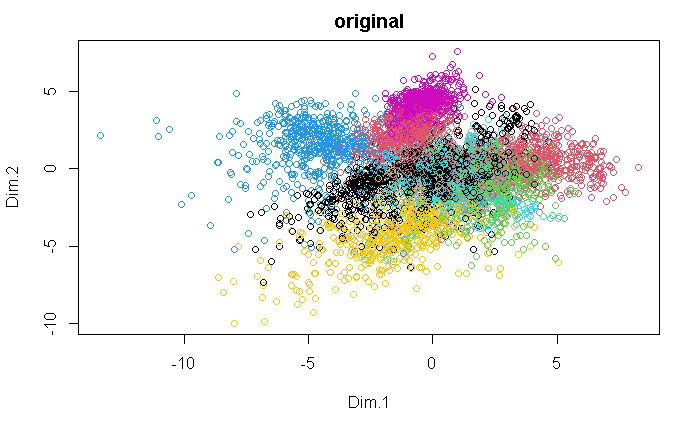

```r
pred.rmix = as.vector(predictions["partition"])
pred.mclust = as.vector(res.mclust$class)
true_values = as.vector(y_data[,1])

plot(res.PCA$ind$coord,col=true_values, main = "original")
```

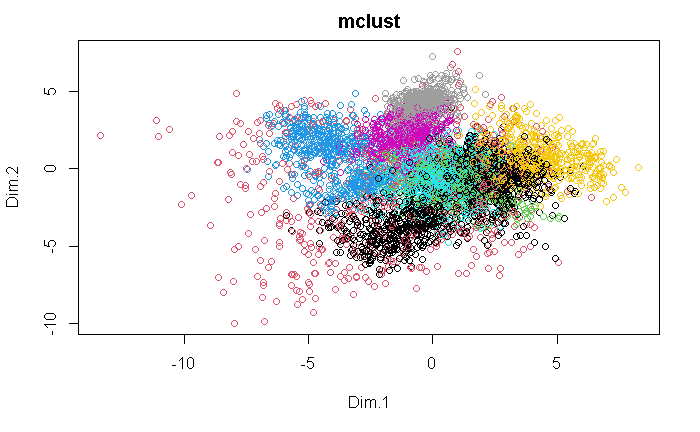

```r
plot(res.PCA$ind$coord,col=pred.mclust, main = "mclust")
```

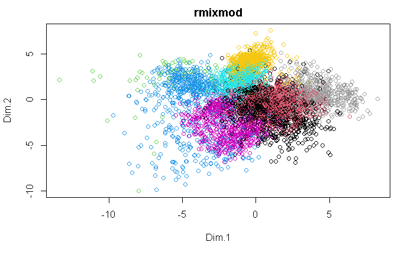

```r
plot(res.PCA$ind$coord,col=pred.rmix, main = "rmixmod")
```

# Q8 : comparer les partitions de mclust et rmixmod

Les resultats des deux packages semblent se rejoindre sur certains clusters tel que le cluster 8 de mclust et 7 de rmixmod, li y’a cependants plusieurs clusters ou les resultats semblent differents pour les deux methodes.

```r
table(pred.rmix,pred.mclust)
```

```
         pred.mclust
pred.rmix   1   2   3   4   5   6   7   8   9  10
       1  171 214 198   4 129   1   1   1  20   0
       2    9   9  80   2  24   0   2   0   0  18
       3    0   2   0   8   0   0   0   0   0  78
       4    0 220   1 370   0   0   0   0  37   0
       5    1   2   0   0   0 538   0   0   0   0
       6    3  45   0 215  12   0   0   0 410   0
       7    2  24   0   0   2   1   0 535   0   5
       8   48  30   0   0   3   0 538   0   0   0
       9    1   1   1   5 698   0   1   0   0   0
       10 680  13 197   0  10   0   0   0   0   0
```

# Q9: MclustDR

MclustDR est une methode de reduction de la dimension linéaire utilisé afin de visualiser le resultat de clustering ou de classification obtenue par des mélanges gaussiens.

```r
res.mclustdr = MclustDR(res.mclust)
summary(res.mclustdr)
```

```
-----------------------------------------------------------------
Dimension reduction for model-based clustering and classification
-----------------------------------------------------------------

Mixture model type: Mclust (VVV, 10)

Clusters   n
      1  915
      2  560
      3  477
      4  604
      5  878
      6  540
      7  542
      8  536
      9  467
      10 101

Estimated basis vectors:
             Dir1       Dir2       Dir3        Dir4      Dir5       Dir6      Dir7      Dir8       Dir9
Dim.1  -0.0593986  0.0046826 -0.0303629  0.03269814 -0.046300  0.1320703 -0.026974  0.092579  0.0339464
Dim.2   0.0206503 -0.0025748  0.0051756  0.01621264 -0.045625  0.1431826  0.036578 -0.055134 -0.1131756
Dim.3   0.0043448  0.0105301 -0.0079849 -0.03162932  0.018403 -0.0017261 -0.062805 -0.034678 -0.0010498
Dim.4  -0.0041886 -0.0074439  0.0130102 -0.00911947  0.102110 -0.0260982 -0.179115  0.150033 -0.5340633
Dim.5   0.1146173  0.0281225  0.0321382  0.18836124  0.050379  0.2798224 -0.347405  0.116477  0.3389029
Dim.6   0.2514226  0.0999145  0.0776344 -0.00022583  0.093142 -0.2074531  0.136408  0.160471  0.0053747
Dim.7   0.0356717 -0.0043207  0.0368094 -0.04961223  0.306883 -0.2352630  0.113060 -0.128925  0.2118138
Dim.8   0.0082392 -0.0206049  0.0313423  0.03775596  0.046031  0.0722850  0.177791 -0.268770 -0.0757107
Dim.9  -0.0014850  0.0933481  0.0664982 -0.03301805  0.183201 -0.4389076 -0.170598  0.086743  0.0751119
Dim.10  0.2146483 -0.0641012  0.0443108  0.42288043  0.227776  0.0922016  0.242703 -0.249603  0.2657904
Dim.11 -0.0270899 -0.2401608  0.0044408 -0.03894704  0.576451  0.1000456  0.230523  0.165743 -0.1288637
Dim.12  0.5045722  0.1036562  0.0844509 -0.00810504 -0.168746  0.2160917  0.405544 -0.125024 -0.3655638
Dim.13 -0.4315916  0.0055137  0.0899694  0.29473882 -0.083829  0.0301143  0.550402  0.562286  0.1043150
Dim.14  0.1442486  0.4037285  0.1881725 -0.13582735 -0.017145  0.2985108  0.116250  0.193077  0.0457695
Dim.15  0.5027352 -0.4962844 -0.4472648 -0.04414833 -0.151593 -0.0702304  0.054578  0.445364  0.0975243
Dim.16  0.1686882  0.5574175 -0.1295710 -0.16632817  0.159506 -0.0222850  0.064380  0.331873  0.1016912
Dim.17 -0.2367135 -0.0838144 -0.1970176 -0.68996158  0.080102  0.3328984  0.290422 -0.103228  0.2924662
Dim.18 -0.2568207  0.0296599 -0.1579164  0.33296531 -0.014348 -0.0609179  0.126174 -0.097556 -0.3606474
Dim.19  0.0686065 -0.4044563  0.7442253 -0.21500901  0.083797  0.2314200 -0.126439  0.202617 -0.0249001
Dim.20  0.0440541 -0.1257554  0.3129237 -0.09295676 -0.601578 -0.5080188  0.181029  0.020309  0.2444428
```

[output cut: 34 more lines]

```
Dim.13  0.1276469  0.0243538
Dim.14  0.0834313  0.1265193
Dim.15  0.0441619 -0.1373584
Dim.16 -0.4479604 -0.4383778
Dim.17  0.3159610 -0.0437252
Dim.18  0.2102192 -0.5649603
Dim.19  0.0232316 -0.2245316
Dim.20 -0.4020695 -0.3184043

              Dir1   Dir2   Dir3   Dir4    Dir5    Dir6    Dir7    Dir8    Dir9   Dir10    Dir11    Dir12
Eigenvalues 54.055 52.530 49.824 24.564  9.8025  4.5605  3.8574  2.0394  1.2984  1.1475  0.84014  0.77864
Cum. %      25.813 50.898 74.691 86.421 91.1025 93.2803 95.1224 96.0963 96.7163 97.2643 97.66553 98.03736
               Dir13    Dir14    Dir15    Dir16    Dir17    Dir18    Dir19     Dir20
Eigenvalues  0.75702  0.67546  0.62595  0.55118  0.52107  0.42523  0.32895   0.22506
Cum. %      98.39887 98.72142 99.02034 99.28355 99.53238 99.73544 99.89253 100.00000
```

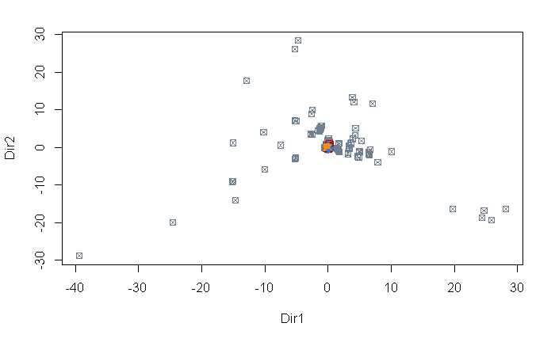

```r
plot(res.mclustdr, what="scatterplot")
```

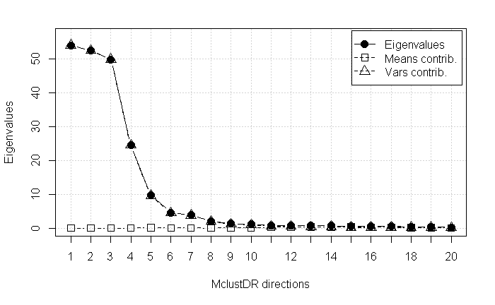

```r
plot(res.mclustdr, what="evalues")
```

# Q10: Comparaison des different algorithmes

D’apres les resultats obtenu, on remarque que le nombre de cluster optimal est bel et bien 10, aussi, mclust semble obtenir les meilleurs resultats sur l’ensemble des methodes, les methodes de melanges en general semble obtenir de bien meilleurs resultats comparé aux algorithmes de clustering standard.

Si nous comparons Mclust à Rmixmod, on voit que mclust semble plus performant. Mclust semble aussi plus rapide, ceci peut étre expliquer par le fait que les deux méthodes utilises de initialisations differente au lancement de leurs algorithmes (cah pour mclust, et un smallEM pour rmixmod), la methode d’initialisation de mclust semble plus rapide et donner de meilleurs resultats en moyenne.

```r
library(clusterSim)
library(aricode)

pred.rmix = as.vector(predictions["partition"])
pred.mclust = as.vector(res.mclust$class)
true_values = as.vector(y_data[,1])


print(paste("Rmixmod taux de mal classé : ", 1- comparing.Partitions(pred.rmix,true_values)))
```

```
[1] "Rmixmod taux de mal classé :  0.421325033912081"
```

```r
print(paste("Mclust taux de mal classé : ", 1-comparing.Partitions(pred.mclust,true_values)))
```

```
[1] "Mclust taux de mal classé :  0.328192997333297"
```

```r
print(paste("cah ward taux de mal classé : ", 1-comparing.Partitions(res_cah_ward$Best.partition,true_values)))
```

```
[1] "cah ward taux de mal classé :  0.704677760103431"
```

```r
print(paste("cah average taux de mal classé : ", 1-comparing.Partitions(res_cah_average$Best.partition,true_values)))
```

```
[1] "cah average taux de mal classé :  0.511912653851414"
```

```r
print(paste("cah complete de mal classé : ", 1-comparing.Partitions(res_cah_complete$Best.partition,true_values)))
```

```
[1] "cah complete de mal classé :  0.743018629760765"
```

```r
print(paste("cah singe  taux de mal classé : ", 1-comparing.Partitions(res_cah_single$Best.partition,true_values)))
```

```
[1] "cah singe  taux de mal classé :  0.914833853847746"
```

```r
print(paste("kmeans  taux de mal classé : ", 1-comparing.Partitions(res_cah_kmeans$Best.partition,true_values)))
```

```
[1] "kmeans  taux de mal classé :  0.727576439212023"
```

```r
print("")
```

```
[1] ""
```

```r
print("")
```

```
[1] ""
```

```r
print(paste("Rmixmod ARI : ",adjustedRandIndex(pred.rmix,true_values)))
```

```
[1] "Rmixmod ARI :  0.493004787349848"
```

```r
(paste("Mclust ARI : ",adjustedRandIndex(pred.mclust,true_values)))
```

```
[1] "Mclust ARI :  0.603267293535736"
```

```r
print(paste("cah_ward ARI : ",adjustedRandIndex(res_cah_ward$Best.partition,true_values)))
```

```
[1] "cah_ward ARI :  0.242986744689931"
```

```r
(paste("cah_average ARI : ",adjustedRandIndex(res_cah_average$Best.partition,true_values)))
```

```
[1] "cah_average ARI :  0.493979650714044"
```

```r
(paste("cah_complete ARI : ",adjustedRandIndex(res_cah_complete$Best.partition,true_values)))
```

```
[1] "cah_complete ARI :  0.213719447547079"
```

```r
(paste("cah_single ARI : ",adjustedRandIndex(res_cah_single$Best.partition,true_values)))
```

```
[1] "cah_single ARI :  -3.0653385691481e-07"
```

```r
(paste("kmeans ARI : ",adjustedRandIndex(res_cah_kmeans$Best.partition,true_values)))
```

```
[1] "kmeans ARI :  0.211630892908094"
```

```r
print("")
```

```
[1] ""
```

```r
print("")
```

```
[1] ""
```

```r
print(paste("Rmixmod NMI : ",NMI(pred.rmix,true_values)))
```

```
[1] "Rmixmod NMI :  0.613897379789771"
```

```r
(paste("Mclust NMI : ",NMI(pred.mclust,true_values)))
```

```
[1] "Mclust NMI :  0.704487458813438"
```

```r
print(paste("cah_ward NMI : ",NMI(res_cah_ward$Best.partition,true_values)))
```

```
[1] "cah_ward NMI :  0.375145178993653"
```

```r
(paste("cah_average NMI : ",NMI(res_cah_average$Best.partition,true_values)))
```

```
[1] "cah_average NMI :  0.615464982112982"
```

```r
(paste("cah_complete NMI : ",NMI(res_cah_complete$Best.partition,true_values)))
```

```
[1] "cah_complete NMI :  0.27158926974186"
```

```r
(paste("cah_single NMI : ",NMI(res_cah_single$Best.partition,true_values)))
```

```
[1] "cah_single NMI :  0.000533570106021621"
```

```r
(paste("kmeans NMI : ",NMI(res_cah_kmeans$Best.partition,true_values)))
```

```
[1] "kmeans NMI :  0.285145678341645"
```

# Q11: TSNE

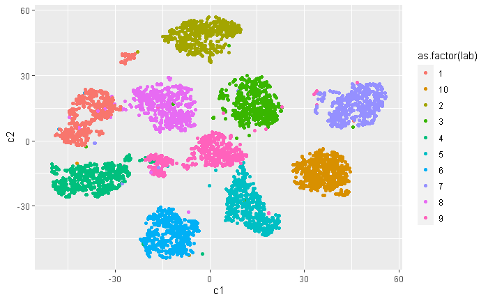

```r
tnse_df = as.data.frame(tsne_res$Y)
tnse_df = cbind(tnse_df,true_values, pred.rmix, pred.mclust)
names(tnse_df) = c("c1", "c2", "lab", "rmix", "mclust")
ggplot(tnse_df, aes(c1, y=c2, color=as.factor(lab)) ) + geom_point()
```

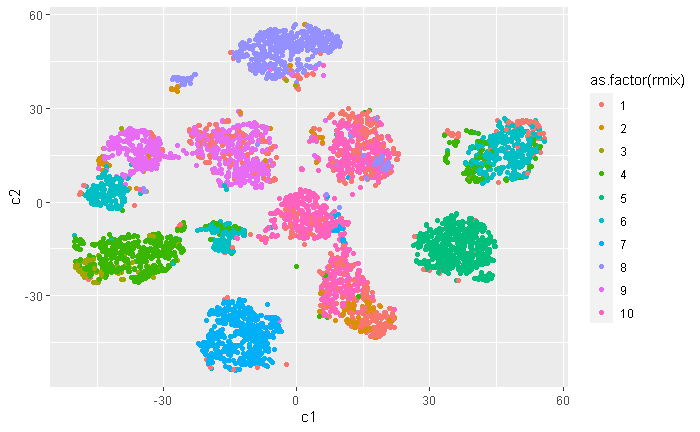

```r
ggplot(tnse_df, aes(c1, y=c2, color=as.factor(rmix)) ) + geom_point()
```

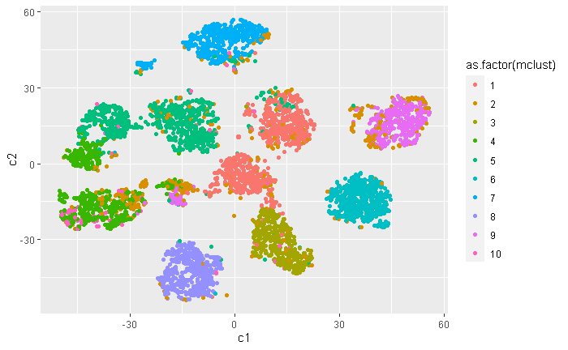

```r
ggplot(tnse_df, aes(c1, y=c2, color=as.factor(mclust))) + geom_point()
```

# Q12 : Reduction par autoencoder

On remarque des resultats casiment equivalent pour les deux methodes, rmixmod ayant eu des resultats legerement superieur pour accuracy et l’ARI, par contre mclust est superieur pour la NMI. De maniére plus general la methode de reduction de dimension à l’aide d’auto encoder semble donner de meilleurs résultats et extraire plus d’informations (en particulier des relations non lineaire) que PCA.

```r
h2o.init()
```

[output not shown]

```
Your H2O cluster version is too old (3 months and 20 days)!
Please download and install the latest version from http://h2o.ai/download/
```

```r
ae_model <- h2o.deeplearning(x=c(1:64),
                                  model_id="ae_model",
                                  training_frame=as.h2o(x_data[,1:64]),
                                  activation="Tanh",
                                  ignore_const_cols=FALSE,
                                  autoencoder=TRUE,
                                  hidden=c(32, 16, 8, 16,32),
                                  epochs=50,
                                  reproducible=T,
                                  seed=1)
```

```r
features <- h2o.deepfeatures(ae_model, as.h2o(x_data[,1:64]), layer=3)
```

```r
set.seed(1)
res.mclust=Mclust(features, G = 1:10)
```

```
fitting ...
```

```r
summary(res.mclust$BIC)
```

```
Best BIC values:
            VVV,10     VEV,10      VVV,9
BIC      -2572.956 -3133.4463 -3530.6457
BIC diff     0.000  -560.4902  -957.6895
```

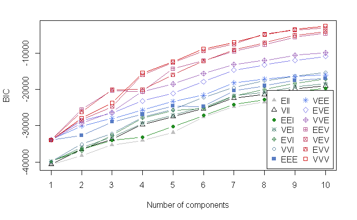

```r
plot(res.mclust,what="BIC")
```

```r
names(res.mclust)
```

```
 [1] "call"           "data"           "modelName"      "n"              "d"              "G"
 [7] "BIC"            "loglik"         "df"             "bic"            "icl"            "hypvol"
[13] "parameters"     "z"              "classification" "uncertainty"
```

```r
table(res.mclust$class,as.vector(y_data[,1]))
```

```
       1  10   2   3   4   5   6   7   8   9
  1    2   5   1 557   0  58   2   1  40 382
  2    0   2   0   0 516   0   0   1   1   0
  3    0   0   0   1   0 480   0   0   0   1
  4    4   0   1   7   0   1   0   0 452   3
  5    0 543   0   0   0   0   0   0   0   0
  6    0   0   0   0   1   0   0 537   2   8
  7   41   0 532   1   0   0   0   0   1   0
  8    0   0   0   0   4   0 542   0   0   0
  9  247   4  23   6  47  19  13  27  47 168
  10 277   0   0   0   0   0   1   0  11   0
```

```r
res.mclust$modelName
```

```
[1] "VVV"
```

```r
adjustedRandIndex(res.mclust$class,as.vector(y_data[,1]))
```

```
[1] 0.7214365
```

```r
res.mixmod = mixmodCluster(data=as.data.frame(features),nbCluster=1:10,models=mixmodGaussianModel(listModels = c("Gaussian_p_Lk_Ck", "Gaussian_pk_Lk_Ck")))
```

```r
predictions= mixmodPredict(as.data.frame(features), classificationRule=res.mixmod["bestResult"])
```

```r
pred.rmix = as.vector(predictions["partition"])
pred.mclust = as.vector(res.mclust$class)
true_values = as.vector(y_data[,1])

print(paste("Rmixmod taux de bien classé : ", comparing.Partitions(pred.rmix,true_values)))
```

```
[1] "Rmixmod taux de bien classé :  0.788303124572283"
```

```r
print(paste("Mclust taux de bien classé : ", comparing.Partitions(pred.mclust,true_values)))
```

```
[1] "Mclust taux de bien classé :  0.7814346587895"
```

```r
print(paste("Rmixmod ARI : ",adjustedRandIndex(pred.rmix,true_values)))
```

```
[1] "Rmixmod ARI :  0.721791364740339"
```

```r
(paste("Mclust ARI : ",adjustedRandIndex(pred.mclust,true_values)))
```

```
[1] "Mclust ARI :  0.721436529038347"
```

```r
print(paste("Rmixmod NMI : ",NMI(pred.rmix,true_values)))
```

```
[1] "Rmixmod NMI :  0.790976162919322"
```

```r
(paste("Mclust NMI : ",NMI(pred.mclust,true_values)))
```

```
[1] "Mclust NMI :  0.804310111267096"
```

[output not shown]